# gb_cource_project

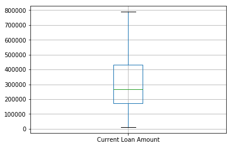

```python
df.loc[df['Current Loan Amount'] < 0.9*10**8].boxplot(['Current Loan Amount'])
```

```
(7312, 17)
```

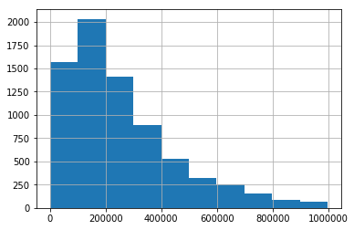

```python
# Current Credit Balance
# Выглядит гораздо лучше
df.loc[df['Current Credit Balance'] < 10**6]['Current Credit Balance'].hist()
df.loc[df['Current Credit Balance'] < 10**6].shape
```

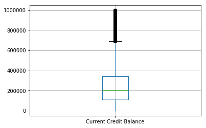

```python
df.loc[df['Current Credit Balance'] < 10**6].boxplot(['Current Credit Balance'])
```

```
(7253,)
```

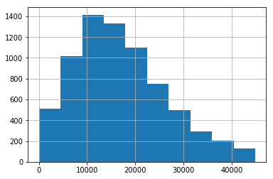

```python
# Monthly Debt

df.loc[df['Monthly Debt'] < 45000]['Monthly Debt'].hist()
df.loc[df['Monthly Debt'] < 45000]['Monthly Debt'].shape
```

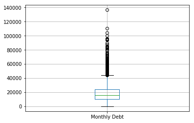

```python
df.loc[df['Monthly Debt'] < 450000].boxplot(['Monthly Debt'])
```

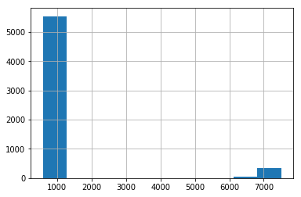

```python
# Monthly Debt
# Не уверен, какие значения кредитного скоринга допустимы, но решаю то, что выше 760 делить на 10.
df['Credit Score'].hist()
```

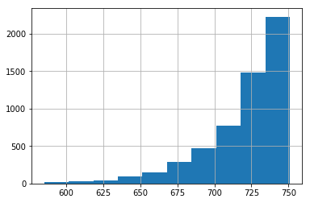

```python
df.loc[df['Credit Score'] < 760]['Credit Score'].hist()
```

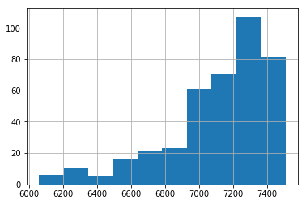

```python
# потому что они похожи на нормальные данные, умноженные на 10
df.loc[df['Credit Score'] >= 760]['Credit Score'].hist()
```

```python
# Сделать после преобразования данных к числам
# !pip install pandas-profiling
# import pandas_profiling
```

```python
# pandas_profiling.ProfileReport(df)
```

```python
# Любопытная закономерность - скоринг и годовой доход пропущены в одинаковых количествах.
# Посмотрим на то, совпадаю ли они построчно
df.loc[pd.isnull(df['Annual Income']) & pd.isnull(df['Credit Score'])].shape
```

```
(1557, 17)
```

Резюмирую действия.

Annual Income 1557 - заполнение пропусков медианной

Tax Liens 0 - ничего не делаем

Number of Open Accounts 0 - ничего не делаем

Years of Credit History 0 - ограничиваем сверху априорным знанием о максимуме сохраняемой кредитной истории. df.loc[df['Years of Credit History'] < 30] выбросы заполняем медианой. **Сейчас пропустим**

Maximum Open Credit 0 - ограничиваем сверху, выбросы = медиана. df.loc[df['Maximum Open Credit'] < 0.5*10**7]['Maximum Open Credit']

Number of Credit Problems 0 - ничего не делаем

Months since last delinquent 4081 - отсутствующие значения = нуль

Bankruptcies 14 - отсутствующие значения = нуль

Purpose 0 - преобразуем в дамми-переменные

Term 0 - создаём тип переменных Длительный? Да/Нет

Current Loan Amount 0 - ограничиваем сверху, пропуски - медианой. df.loc[df['Current Loan Amount'] < 0.2*10**8]['Current Loan Amount']

Current Credit Balance 0 - ограничиваем сверху, пропуски - медианой. df.loc[df['Current Credit Balance'] < 10**6]['Current Credit Balance']

Monthly Debt 0 - ограничиваем сверху. Пропуски - медианой df.loc[df['Monthly Debt'] < 45000]['Monthly Debt']

Credit Score 1557 - ограничиваю сверху 760. то, что выше 760 делить на 10. Пропуски - медианой.

Credit Default 0

```python
new = df.copy()
```

```python
new.loc[new['Current Loan Amount'] >= 0.2*(10**8), 'Current Loan Amount'] =  new.loc[new['Current Loan Amount'] < 0.2*(10**8), 'Current Loan Amount'].median()
```

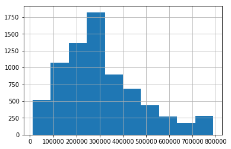

```python
new['Current Loan Amount'].hist()
```

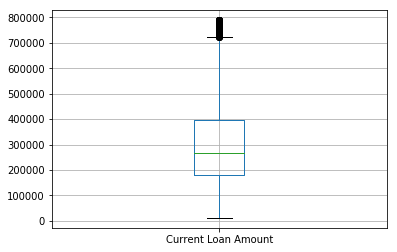

```python
new.boxplot(['Current Loan Amount'])
```

```python
new.loc[new['Credit Score'] > 760, 'Credit Score'] = new.loc[new['Credit Score'] > 760, 'Credit Score'] / 10
```

```python
new.loc[:,'Credit Score'] = new['Credit Score'].fillna(new['Credit Score'].median())
```

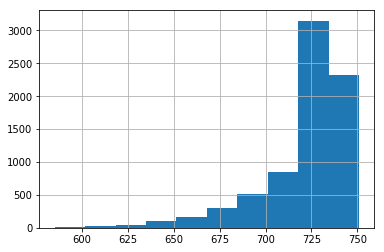

```python
new['Credit Score'].hist()
```

```python
new.loc[:, 'Annual Income'] = new['Annual Income'].fillna(new['Annual Income'].median())
```

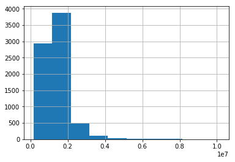

```python
new['Annual Income'].hist()
```

```python
new['Years in current job'].value_counts()
```

```
10+ years    2332
2 years       705
3 years       620
< 1 year      563
5 years       516
1 year        504
4 years       469
6 years       426
7 years       396
nan           371
8 years       339
9 years       259
Name: Years in current job, dtype: int64
```

```python
new['JOB YEARS'] = 0
for i in range(len(new['Years in current job'])):
    # пропуски заменяем на самые частые - '10+ years'
    if new['Years in current job'].iloc[i] == '< 1 year':
        new['JOB YEARS'].iloc[i] = 0
    elif new['Years in current job'].iloc[i] == '1 year':
        new['JOB YEARS'].iloc[i] = 1
    elif new['Years in current job'].iloc[i] == '2 years':
        new['JOB YEARS'].iloc[i] = 2
    elif new['Years in current job'].iloc[i] == '3 years':
        new['JOB YEARS'].iloc[i] = 3
    elif new['Years in current job'].iloc[i] == '4 years':
        new['JOB YEARS'].iloc[i] = 4
    elif new['Years in current job'].iloc[i] == '5 years':
        new['JOB YEARS'].iloc[i] = 5
    elif new['Years in current job'].iloc[i] == '6 years':
        new['JOB YEARS'].iloc[i] = 6
    elif new['Years in current job'].iloc[i] == '7 years':
        new['JOB YEARS'].iloc[i] = 7
    elif new['Years in current job'].iloc[i] == '8 years':
        new['JOB YEARS'].iloc[i] = 8
    elif new['Years in current job'].iloc[i] == '9 years':
        new['JOB YEARS'].iloc[i] = 9
    else:
        new['JOB YEARS'].iloc[i] = 10
```

```python
# Сверим получившиеся значения
new['JOB YEARS'].value_counts()
```

```
10    2703
2      705
3      620
0      563
5      516
1      504
4      469
6      426
7      396
8      339
9      259
Name: JOB YEARS, dtype: int64
```

```python
 new['Years in current job'].value_counts()
```

```
10+ years    2332
2 years       705
3 years       620
< 1 year      563
5 years       516
1 year        504
4 years       469
6 years       426
7 years       396
nan           371
8 years       339
9 years       259
Name: Years in current job, dtype: int64
```

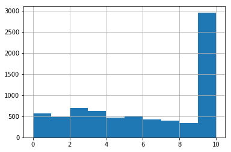

```python
 new['JOB YEARS'].hist()
```

```
array([<matplotlib.axes._subplots.AxesSubplot object at 0x0000029240B8AFD0>,
      dtype=object)
```

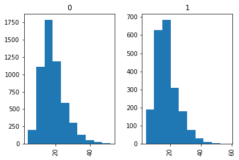

```python
df.loc[df['Years of Credit History'] < 300]['Years of Credit History'].hist(by=df['Credit Default'])
# Пока сомневаюсь, стоит ли вообще что-либо делать с этими значениями
```

```python
new.loc[new['Maximum Open Credit'] > 0.5*10**7, 'Maximum Open Credit'] = df.loc[df['Maximum Open Credit'] < 0.5*10**7]['Maximum Open Credit'].median()
```

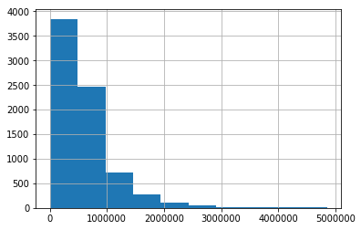

```python
new['Maximum Open Credit'].hist()
```

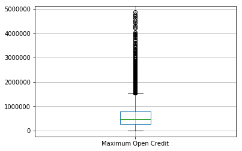

```python
new.boxplot(['Maximum Open Credit'])
```

```python
new.loc[new['Current Credit Balance'] >= 10**6, 'Current Credit Balance'] = df.loc[df['Current Credit Balance'] < 10**6]['Current Credit Balance'].median()
```

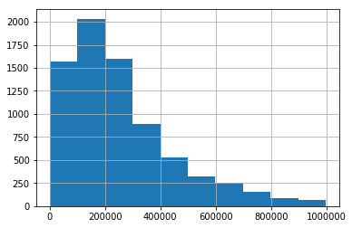

```python
new['Current Credit Balance'].hist()
```

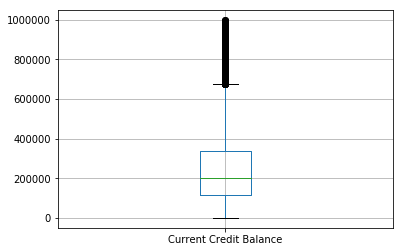

```python
new.boxplot(['Current Credit Balance'])
```

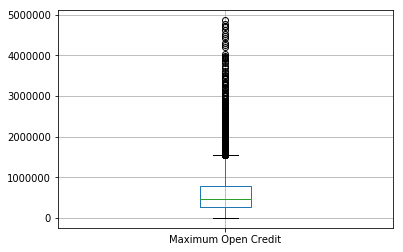

```python
new.boxplot(['Maximum Open Credit'])
# В целом, можно ограничить полутора миллионами, но не понятно, как быть - есть же те, кто берёт большие кредиты.
```

```python
new.loc[:, 'Months since last delinquent'] = new['Months since last delinquent'].fillna(0.0)
```

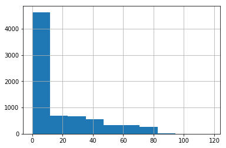

```python
new['Months since last delinquent'].hist()
```

```python
new.loc[:, 'Bankruptcies'] = new['Bankruptcies'].fillna(0.0)
```

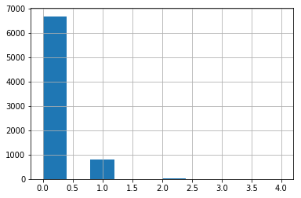

```python
new['Bankruptcies'].hist()
```

```python
new['Term'].value_counts()
```

```
Short Term    5556
Long Term     1944
Name: Term, dtype: int64
```

```python
new['IS_LONG'] = new['Term'].map({'Long Term': '1', 'Short Term':'0'}).astype(int)
```

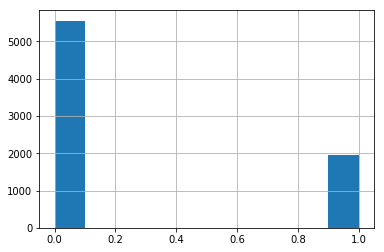

```python
new['IS_LONG'].hist()
```

```python
new['IS_LONG'].value_counts()
```

```
0    5556
1    1944
Name: IS_LONG, dtype: int64
```

```python
new.loc[new['Monthly Debt'] >= 45000, 'Monthly Debt'] = df.loc[df['Monthly Debt'] < 45000, 'Monthly Debt'].median()
```

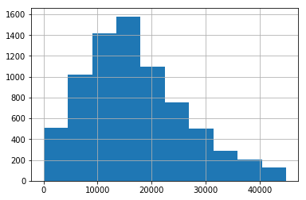

```python
new['Monthly Debt'].hist()
```

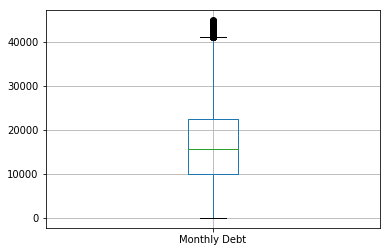

```python
new.boxplot(['Monthly Debt'])
```

```python
new.select_dtypes(include='object')
del new['Years in current job']
del new['Term']
```

```python
new['Home Ownership'].value_counts()
```

```
Home Mortgage    3637
Rent             3204
Own Home          647
Have Mortgage      12
Name: Home Ownership, dtype: int64
```

```python
new.loc[new['Home Ownership'] == 'Have Mortgage', 'Home Ownership'] = 'Home Mortgage'
```

```python
new['Home Ownership'].value_counts()
```

```
Home Mortgage    3649
Rent             3204
Own Home          647
Name: Home Ownership, dtype: int64
```

```python
# test = new.copy()
# for cat_colname in test.select_dtypes(include='object').columns[1:]:
#     test = pd.concat([test, pd.get_dummies(test[cat_colname], prefix=cat_colname)], axis=1)
```

```python
for cat_colname in new.select_dtypes(include='object').columns[1:]:
    new = pd.concat([new, pd.get_dummies(new[cat_colname], prefix=cat_colname)], axis=1)
```

```python
new.select_dtypes(include='object')
del new['Home Ownership']
del new['Purpose']
```

```python
new.select_dtypes(include='object')
```

| 0 |
| --- |
| 1 |
| 2 |
| 3 |
| 4 |
| ... |
| 7495 |
| 7496 |
| 7497 |
| 7498 |
| 7499 |

7500 rows × 0 columns

```python
len(new) - new.count()
```

```
Annual Income                   0
Tax Liens                       0
Number of Open Accounts         0
Years of Credit History         0
Maximum Open Credit             0
Number of Credit Problems       0
Months since last delinquent    0
Bankruptcies                    0
Current Loan Amount             0
Current Credit Balance          0
Monthly Debt                    0
Credit Score                    0
Credit Default                  0
JOB YEARS                       0
IS_LONG                         0
Purpose_business loan           0
Purpose_buy a car               0
Purpose_buy house               0
Purpose_debt consolidation      0
Purpose_educational expenses    0
Purpose_home improvements       0
Purpose_major purchase          0
Purpose_medical bills           0
Purpose_moving                  0
Purpose_other                   0
Purpose_renewable energy        0
Purpose_small business          0
Purpose_take a trip             0
Purpose_vacation                0
Purpose_wedding                 0
dtype: int64
```

```python
new.describe()
```

|  | Annual Income | Tax Liens | Number of Open Accounts | Years of Credit History | Maximum Open Credit | Number of Credit Problems | Months since last delinquent | Bankruptcies | Current Loan Amount | Current Credit Balance | ... | Purpose_home improvements | Purpose_major purchase | Purpose_medical bills | Purpose_moving | Purpose_other | Purpose_renewable energy | Purpose_small business | Purpose_take a trip | Purpose_vacation | Purpose_wedding |
| --- | --- | --- | --- | --- | --- | --- | --- | --- | --- | --- | --- | --- | --- | --- | --- | --- | --- | --- | --- | --- | --- |
| count | 7.500000e+03 | 7500.000000 | 7500.000000 | 7500.000000 | 7.500000e+03 | 7500.000000 | 7500.000000 | 7500.000000 | 7500.000000 | 7500.000000 | ... | 7500.000000 | 7500.000000 | 7500.000000 | 7500.000000 | 7500.000000 | 7500.000000 | 7500.000000 | 7500.000000 | 7500.000000 | 7500.00000 |
| mean | 1.325286e+06 | 0.030133 | 11.130933 | 18.317467 | 6.150970e+05 | 0.170000 | 15.815200 | 0.116933 | 304013.377067 | 253707.613067 | ... | 0.054933 | 0.005333 | 0.009467 | 0.001467 | 0.088667 | 0.000267 | 0.003467 | 0.004933 | 0.001067 | 0.00200 |
| std | 7.567551e+05 | 0.271604 | 4.908924 | 7.041946 | 5.227771e+05 | 0.498598 | 22.649441 | 0.346904 | 171951.057747 | 193887.193059 | ... | 0.227865 | 0.072840 | 0.096842 | 0.038272 | 0.284281 | 0.016329 | 0.058780 | 0.070069 | 0.032645 | 0.04468 |
| min | 1.645970e+05 | 0.000000 | 2.000000 | 4.000000 | 0.000000e+00 | 0.000000 | 0.000000 | 0.000000 | 11242.000000 | 0.000000 | ... | 0.000000 | 0.000000 | 0.000000 | 0.000000 | 0.000000 | 0.000000 | 0.000000 | 0.000000 | 0.000000 | 0.00000 |
| 25% | 9.311330e+05 | 0.000000 | 8.000000 | 13.500000 | 2.792295e+05 | 0.000000 | 0.000000 | 0.000000 | 180169.000000 | 114256.500000 | ... | 0.000000 | 0.000000 | 0.000000 | 0.000000 | 0.000000 | 0.000000 | 0.000000 | 0.000000 | 0.000000 | 0.00000 |
| 50% | 1.168386e+06 | 0.000000 | 10.000000 | 17.000000 | 4.752880e+05 | 0.000000 | 0.000000 | 0.000000 | 265826.000000 | 203490.000000 | ... | 0.000000 | 0.000000 | 0.000000 | 0.000000 | 0.000000 | 0.000000 | 0.000000 | 0.000000 | 0.000000 | 0.00000 |
| 75% | 1.499974e+06 | 0.000000 | 14.000000 | 21.800000 | 7.837280e+05 | 0.000000 | 29.000000 | 0.000000 | 396929.500000 | 338314.000000 | ... | 0.000000 | 0.000000 | 0.000000 | 0.000000 | 0.000000 | 0.000000 | 0.000000 | 0.000000 | 0.000000 | 0.00000 |
| max | 1.014934e+07 | 7.000000 | 43.000000 | 57.700000 | 4.860504e+06 | 7.000000 | 118.000000 | 4.000000 | 789030.000000 | 997899.000000 | ... | 1.000000 | 1.000000 | 1.000000 | 1.000000 | 1.000000 | 1.000000 | 1.000000 | 1.000000 | 1.000000 | 1.00000 |

8 rows × 30 columns

```python
new.to_csv(PREP_DATASET_PATH, index=False, encoding='utf-8')
```

```python
df_base = new.copy()
```

```python
TARGET_NAME = 'Credit Default'
BASE_FEATURE_NAMES = df_base.columns.drop(TARGET_NAME).tolist()
NEW_FEATURE_NAMES = new.columns.drop([TARGET_NAME] + BASE_FEATURE_NAMES)
```

```python
from scipy.stats import shapiro
from scipy.stats import probplot
from scipy.stats import ttest_ind, mannwhitneyu
from scipy.stats import chi2_contingency
from statsmodels.stats.weightstats import zconfint

import seaborn as sns
from matplotlib import pyplot as plt
%matplotlib inline
```

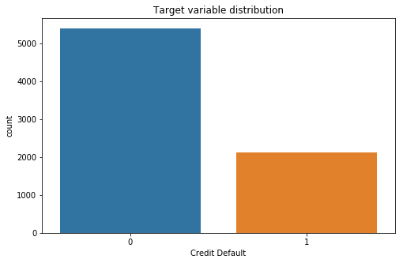

```python
plt.figure(figsize=(8, 5))

sns.countplot(x=TARGET_NAME, data=df)

plt.title('Target variable distribution')
plt.show()
```

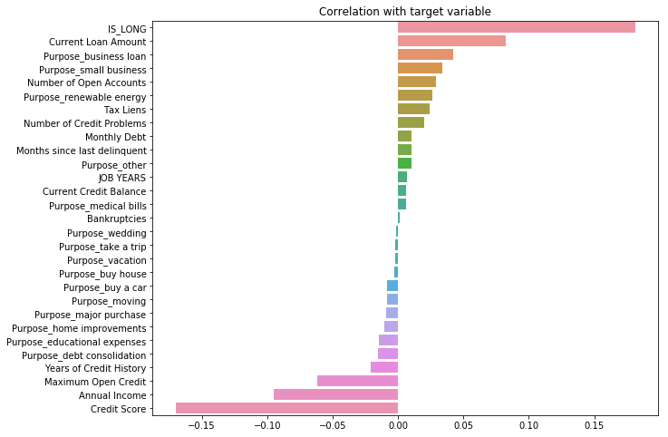

```python
corr_with_target = new[BASE_FEATURE_NAMES + [TARGET_NAME]].corr().iloc[:-1, -1].sort_values(ascending=False)

plt.figure(figsize=(10, 8))

sns.barplot(x=corr_with_target.values, y=corr_with_target.index)

plt.title('Correlation with target variable')
plt.show()
```

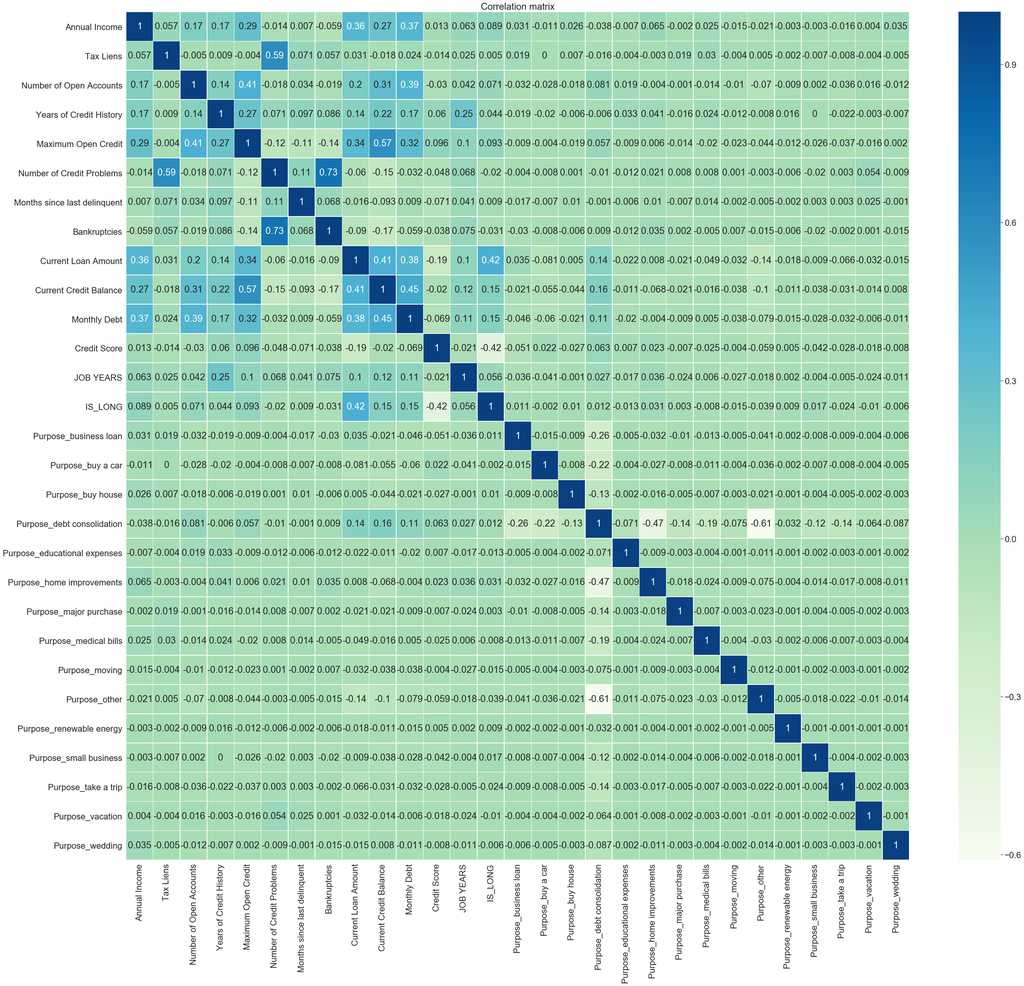

```python
plt.figure(figsize = (45,40))

sns.set(font_scale=2)
sns.heatmap(new[BASE_FEATURE_NAMES].corr().round(3), annot=True, linewidths=.5, cmap='GnBu')

plt.title('Correlation matrix')
plt.show()
```